# Your mission

Perform text analysis.

## Okay, I need more information

Perform sentiment analysis or topic modeling using text analysis methods as demonstrated in the pre-class work and in the readings.

## Okay, I need even more information.

Do the above. Can’t think of a data source?

Analyze the text for sentiment OR topic. **You do not need to do both**. The datacamp courses and [Tidy Text Mining with R](http://tidytextmining.com/) are good starting points for templates to perform this type of analysis, but feel free to *expand beyond these examples*.

# Timelines and Task

We will spend the next 2 weeks working on analyzing textual data in R. You will do the following:

- Start with some text based data.
- Clean data and prepare it for analysis
- Ask questions about the data
- Answer these questions with the data using tables and graphics
- Each group member must have their own unique question that they code the answer for.

## SET UP

```r
# Get libraries
library(tidytext)
library(dplyr)
library(rebus)
library(stringr)
```

```r
library(ggplot2)
```

## Prepare Titles and Sentiment Scores

```r
# Get Data
library(RTextTools)
data(NYTimes)


# Get dictionary with sentiment scores using lexicon afinn
sentiment.scores = as.data.frame(get_sentiments("afinn"))

# Prepare the titles as strings by converting title to characters
NYTimes$title = (as.character(NYTimes$Title))
```

# Sentiments of NY Times Titles

## Intensity of Negative and Positive Words in NY Times Titles

This section looks at what the frequency distribution of the intensity of negative and positive words used in the NY Times titles are.

```r
# Create a data frame that will contain the sentiment scores for each word in the title
scores = NYTimes %>%
  # group the data by title
  group_by(Title) %>%
  # get each word from the title out by unnesting
  unnest_tokens(output=word, input=title) %>%
  # get the sentiment scores for each word in the title
  inner_join(sentiment.scores) %>%
  # get a mean of the score for each word in the title to get an average sentiment score for each title
  summarize(title.score = mean(score))
```

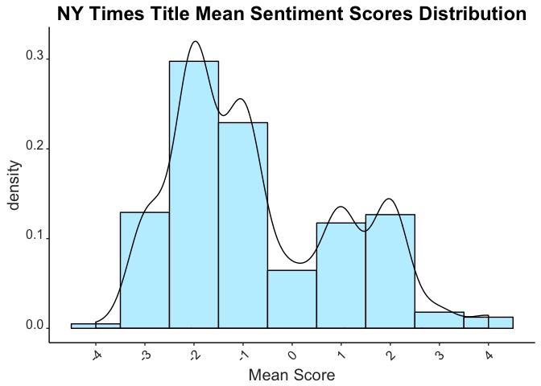

```r
# plot mean scores for each title

ggplot(scores,aes(title.score)) +
  labs(x = "Mean Score") +
  geom_histogram(color="black",fill="lightblue1",aes(y=..density..), binwidth=1) +
  geom_density() +
  scale_x_continuous(breaks = pretty(scores$title.score, n = 10)) +
  ggtitle("NY Times Title Mean Sentiment Scores Distribution") +
  theme(plot.title = element_text(color="black", face="bold", size=18,hjust = 0.5)) +
  #theme_bw() +
  theme(panel.border = element_blank(), panel.grid.major = element_blank(),
        panel.grid.minor = element_blank(), axis.line = element_line(colour = "black")) +
 theme(panel.background = element_rect(fill='white')) +
  theme(axis.text.x = element_text(colour="grey20",size=12,angle=45,hjust=.5,vjust=.5,face="plain"),
        axis.text.y = element_text(colour="grey20",size=12,angle=0,hjust=1,vjust=0,face="plain"),
        axis.title.x = element_text(colour="grey20",size=15,angle=0,hjust=.5,vjust=0,face="plain"),
        axis.title.y = element_text(colour="grey20",size=15,angle=90,hjust=.5,vjust=.5,face="plain"))
```

This plot shows the frequency of the mean intensities of positive/negative words used in the titles. A higher absolute value indicates greater intensity of an emotion in words for the title, whereas a lower one indicates less intensity. Negative numbers indicate negative emotions whereas positive numbers indicate positive emotions.

## Extremeness of Emotional Words Used in NY Times Titles

This section looks at just how intense the emotions of the words in NY Times titles are (i.e., it doesn’t matter whether the emotions are negative or positive; we are just interested in how extreme these emotions get).

```r
# We do the same thing as Part 1a except now, if the scores are negative, we get the absolute value of them.

# Create a data frame that will contain the sentiment scores for each word in the title
scores = NYTimes %>%
  # group the data by title
  group_by(Title) %>%
  # get each word from the title out by unnesting
  unnest_tokens(output=word, input=title) %>%
  # get the sentiment scores for each word in the title
  inner_join(sentiment.scores) %>%
  # get the absolute value of the sentiment scores so that we get the intensity score
  mutate(intensity.score = abs(score))
```

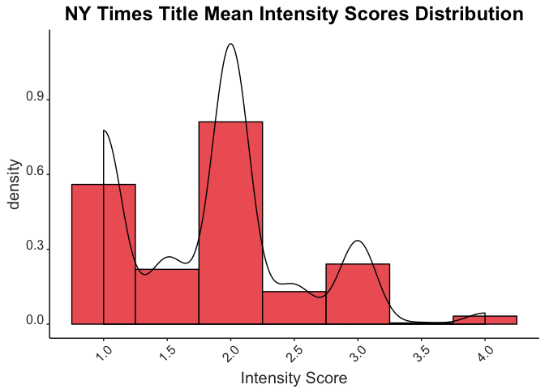

```r
# get a mean of the intensity for each titles
scores = scores %>%
  group_by(Title) %>%
  summarize(title.intensity.score = mean(intensity.score))

# plot mean scores for each title
ggplot(scores,aes(title.intensity.score)) +
  # label the x-axis
  labs(x = "Intensity Score") +
  # create histogram with a density curve
  geom_histogram(color="black",fill="indianred2",aes(y=..density..), binwidth=0.5) +
  geom_density() +
  # label the x-axis tick marks in a way that's intuitive
  scale_x_continuous(breaks = pretty(scores$title.intensity.score, n = 10)) +
  # make the title nice
  ggtitle("NY Times Title Mean Intensity Scores Distribution") +
  theme(plot.title = element_text(color="black", face="bold", size=18,hjust = 0.5)) +
  # get the background to be white and get rid of the grid marks
  theme(panel.border = element_blank(), panel.grid.major = element_blank(),
        panel.grid.minor = element_blank(), axis.line = element_line(colour = "black")) +
 theme(panel.background = element_rect(fill='white')) +
  # make the axis tick marks and text look nicer
  theme(axis.text.x = element_text(colour="grey20",size=12,angle=45,hjust=.5,vjust=.5,face="plain"),
        axis.text.y = element_text(colour="grey20",size=12,angle=0,hjust=1,vjust=0,face="plain"),
        axis.title.x = element_text(colour="grey20",size=15,angle=0,hjust=.5,vjust=0,face="plain"),
        axis.title.y = element_text(colour="grey20",size=15,angle=90,hjust=.5,vjust=.5,face="plain"))
```

How is it different by time?

```r
############# Get years

#1. Convert Dates to Strings

# make the date as characters
NYTimes$Date = as.character(NYTimes$Date)

# now convert the date to strings
for (i in 1:length(NYTimes$Date)){
NYTimes$Date[i] = toString(NYTimes$Date[i])
}

#2. Extract the Year
# create a pattern for how the year will look like
year_pattern = DGT %R% DGT %R% END
# get the year using this pattern and put this year in our data frame with scores
NYTimes$year = str_extract(NYTimes$Date, pattern=year_pattern)

# now, create a new data frame that will contain the sentiment scores for titles by year

# first, get the mean sentiment scores for each title
scores2 =
NYTimes %>%
  group_by(Title, year) %>%
   # get each word from the title out by unnesting
  unnest_tokens(output=word, input=title) %>%
  # get the sentiment scores for each word in the title
  inner_join(sentiment.scores) %>%
  # mean score
  summarize(title.score = mean(score))
```

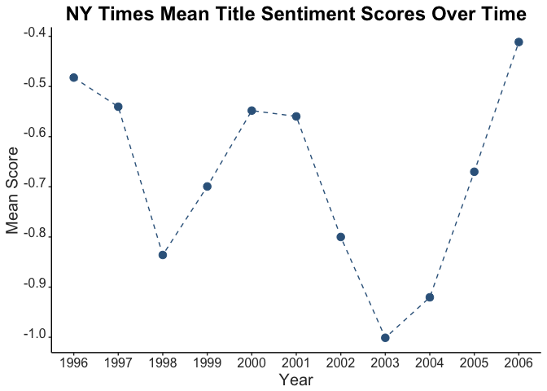

```r
# now, group by year so that we get a mean sentiment score for each year
scores2 =
  scores2 %>%
  group_by(year) %>%
  summarize(year.score = mean(title.score))

# create a new data frame to get the absolute value for each year so that we get intensity scores

scores3 =
  scores2 %>%
  mutate(year.intensity = abs(year.score))

# change the years to be numeric
scores2$year = (as.numeric(scores2$year))

# change the years to be from year 1 to year 10 by making 1996 as year 1 and 2006 as year 10
scores2 = scores2 %>%
  mutate(year.num = ifelse(scores2$year<=6, 10-scores2$year, abs(96-scores2$year)))
scores3$year.num = scores2$year.num

# LINE PLOTS

# This plots the sentiment scores
ggplot(data=scores2, aes(x=year.num,y=year.score)) +
  geom_line(color="steelblue4", linetype="dashed") +
  labs(x = "Year", y = "Mean Score") +
  scale_x_continuous(breaks = pretty(scores2$year.num, n = 10),labels=c(1996:2006)) +
  scale_y_continuous(breaks = pretty(scores2$year.score, n = 8)) +
  geom_point(size=3,color="steelblue4") +
  ggtitle("NY Times Mean Title Sentiment Scores Over Time") +
  theme(plot.title = element_text(color="black", face="bold", size=18,hjust = 0.5)) +
  #theme_bw() +
  theme(panel.border = element_blank(), panel.grid.major = element_blank(),
        panel.grid.minor = element_blank(), axis.line = element_line(colour = "black")) +
  theme(panel.background = element_rect(fill='white')) +
      theme(axis.text.x = element_text(colour="grey20",size=12,angle=0,hjust=.5,vjust=.5,face="plain"),
        axis.text.y = element_text(colour="grey20",size=12,angle=0,hjust=1,vjust=0,face="plain"),
        axis.title.x = element_text(colour="grey20",size=15,angle=0,hjust=.5,vjust=0,face="plain"),
        axis.title.y = element_text(colour="grey20",size=15,angle=90,hjust=.5,vjust=.5,face="plain"))
```

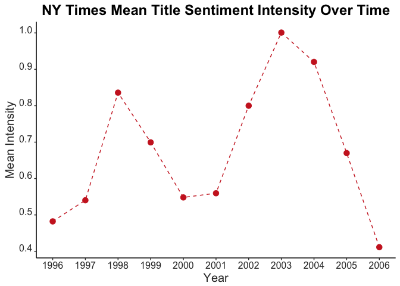

```r
# This plots the intensity scores
ggplot(data=scores3, aes(x=year.num,y=year.intensity)) +
  geom_line(color="firebrick3", linetype="dashed") +
  labs(x = "Year", y = "Mean Intensity") +
  scale_x_continuous(breaks = pretty(scores3$year.num, n = 10),labels=c(1996:2006)) +
  scale_y_continuous(breaks = pretty(scores3$year.intensity, n = 8)) +
  geom_point(size=3,color="firebrick3") +
  ggtitle("NY Times Mean Title Sentiment Intensity Over Time") +
  theme(plot.title = element_text(color="black", face="bold", size=18,hjust = 0.5)) +
  #theme_bw() +
  theme(panel.border = element_blank(), panel.grid.major = element_blank(),
        panel.grid.minor = element_blank(), axis.line = element_line(colour = "black")) +
  theme(panel.background = element_rect(fill='white')) +
      theme(axis.text.x = element_text(colour="grey20",size=12,angle=0,hjust=.5,vjust=.5,face="plain"),
        axis.text.y = element_text(colour="grey20",size=12,angle=0,hjust=1,vjust=0,face="plain"),
        axis.title.x = element_text(colour="grey20",size=15,angle=0,hjust=.5,vjust=0,face="plain"),
        axis.title.y = element_text(colour="grey20",size=15,angle=90,hjust=.5,vjust=.5,face="plain"))
```